# Machine Learning_HAR_Weight Lifting

Maneesh Pandey

April 1, 2018

## Overview:

The project work is based on the paper “Qualitative Activity Recognition of Weight Lifting Exercises” The data for this project come from this source: http://groupware.les.inf.puc-rio.br/har." The authors of this paper using the sensors attached to body of the participants studied “qualitatve”(how well)the excercise was performed, in this case weightlifting using a dumbell of 1.25kg. In this project, goal will be to use data from accelerometers on the belt, forearm, arm, and dumbell of 6 participants. They were asked to perform barbell lifts correctly and incorrectly in 5 different ways. Participants were asked to perform one set of 10 repetitions of the Unilateral Dumbbell Biceps Curl in ???ve di???erent fashions: exactly according to the speci???cation (Class A), throwing the elbows to the front (Class B), lifting the dumbbell only halfway (Class C), lowering the dumbbell only halfway (Class D) and throwing the hips to the front (Class E). Class A corresponds to the speci???ed execution of the exercise, while the other 4 classes correspond to common mistakes. Participants were supervised by an experienced weight lifter to make sure the execution complied to the manner they were supposed to simulate. The aim of this work is to investigate the feasibility of automatically assessing the quality of execution of weight lifting exercises and the impact of providing real-time feedback to the Participant. - so-called qualitative activity recognition.

```r
#importing training data
url1<-"https://d396qusza40orc.cloudfront.net/predmachlearn/pml-training.csv"
loc1<-("~/analytics_case study/machineLearning/training.csv")
download.file(url1,loc1)
#importing testing data
url2<-"https://d396qusza40orc.cloudfront.net/predmachlearn/pml-testing.csv"
loc2<-("~/analytics_case study/machineLearning/testing.csv")
download.file(url2,loc2)
# reading data
training<-read.csv("training.csv",skipNul =TRUE)
testing<-read.csv("testing.csv", skipNul =TRUE)
table(training$classe)
```

```
##
##    A    B    C    D    E
## 5580 3797 3422 3216 3607
```

```r
#training<-training[,(na.rm=TRUE)]
inTrain<-createDataPartition(y=training$classe,p=0.7,list=FALSE)
train_1<-training[inTrain,]
test_1<-training[-inTrain,]
# Removing columns with Near Zero variance in training data,
nzv<-nearZeroVar(train_1,saveMetrics = TRUE)
train_1<-train_1[,nzv$nzv==FALSE]
# Removing coulmns with Near Zero Variance in test data
nzv1<-nearZeroVar(test_1,saveMetrics = TRUE)
test_1<-test_1[,nzv1$nzv==FALSE]
#removing columns with NA's more than 60% in training data
outtrain<-train_1[,colSums(is.na(train_1)/(nrow(train_1)))>=0.6]
del_cols1<-colnames(outtrain)
train_2<-train_1[,!(names(train_1)%in% del_cols1)]
table(train_2$classe)
```

```
##
##    A    B    C    D    E
## 3906 2658 2396 2252 2525
```

```r
#removing X,rawtimestamps,cvtd,numWindow from training and test data
train_2<-train_2[,-c(1,3:6)]
test_2<-test_1[,names(train_2)]
table(test_2$classe)
```

```
##
##    A    B    C    D    E
## 1674 1139 1026  964 1082
```

```r
dim(train_2)
```

```
## [1] 13737    54
```

```r
dim(test_2)
```

```
## [1] 5885   54
```

```r
test_final<-test_2[,-54]
# mapping testing data with same columns as in training data
testing_2<-testing[,names(test_final)]
dim(testing_2)
```

```
## [1] 20 53
```

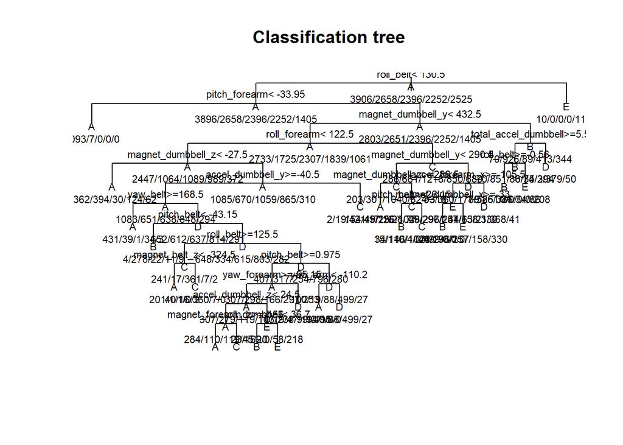

```r
# Preprocessing and training with partitinong and classification
set.seed(55555)
train_fit<-rpart(classe~.,data=train_2,method="class")
#print(train_fit)
plot(train_fit,uniform = TRUE, main="Classification tree")
text(train_fit,use.n = TRUE,all=TRUE, cex=0.7)
```

```r
predict_tree<-predict(train_fit,newdata=test_final,type="class")
confusionMatrix(predict_tree,test_2$classe)
```

```
## Confusion Matrix and Statistics
##
##           Reference
## Prediction    A    B    C    D    E
##          A 1549  246   25  124   56
##          B   46  618   41   17   66
##          C   31   95  837  137   90
##          D   18   89   60  608   57
##          E   30   91   63   78  813
##
## Overall Statistics
##
##                Accuracy : 0.7519
##                  95% CI : (0.7407, 0.7629)
##     No Information Rate : 0.2845
##     P-Value [Acc > NIR] : < 2.2e-16
##
##                   Kappa : 0.6841
##  Mcnemar's Test P-Value : < 2.2e-16
##
## Statistics by Class:
##
##                      Class: A Class: B Class: C Class: D Class: E
## Sensitivity            0.9253   0.5426   0.8158   0.6307   0.7514
## Specificity            0.8929   0.9642   0.9274   0.9545   0.9455
## Pos Pred Value         0.7745   0.7843   0.7034   0.7308   0.7563
## Neg Pred Value         0.9678   0.8978   0.9597   0.9295   0.9441
## Prevalence             0.2845   0.1935   0.1743   0.1638   0.1839
## Detection Rate         0.2632   0.1050   0.1422   0.1033   0.1381
## Detection Prevalence   0.3398   0.1339   0.2022   0.1414   0.1827
## Balanced Accuracy      0.9091   0.7534   0.8716   0.7926   0.8484
```

```r
#model fit with Random forest
set.seed(55555)
rf_fit<-randomForest(classe~.,data=train_2, ntree=250, type ="classification")
pre_rf<-predict(rf_fit,newdata=test_final)
confusionMatrix(pre_rf,test_2$classe)
```

```
## Confusion Matrix and Statistics
##
##           Reference
## Prediction    A    B    C    D    E
##          A 1674    2    0    0    0
##          B    0 1135    3    0    0
##          C    0    2 1023   13    2
##          D    0    0    0  950    1
##          E    0    0    0    1 1079
##
## Overall Statistics
##
##                Accuracy : 0.9959
##                  95% CI : (0.9939, 0.9974)
##     No Information Rate : 0.2845
##     P-Value [Acc > NIR] : < 2.2e-16
##
##                   Kappa : 0.9948
##  Mcnemar's Test P-Value : NA
##
## Statistics by Class:
##
##                      Class: A Class: B Class: C Class: D Class: E
## Sensitivity            1.0000   0.9965   0.9971   0.9855   0.9972
## Specificity            0.9995   0.9994   0.9965   0.9998   0.9998
## Pos Pred Value         0.9988   0.9974   0.9837   0.9989   0.9991
## Neg Pred Value         1.0000   0.9992   0.9994   0.9972   0.9994
## Prevalence             0.2845   0.1935   0.1743   0.1638   0.1839
## Detection Rate         0.2845   0.1929   0.1738   0.1614   0.1833
## Detection Prevalence   0.2848   0.1934   0.1767   0.1616   0.1835
## Balanced Accuracy      0.9998   0.9979   0.9968   0.9926   0.9985
```

```r
#model fit with Lda
set.seed(55555)
lda_fit<-train(classe~.,data=train_2,  method ="lda")
pre_lda<-predict(lda_fit,newdata=test_final)
confusionMatrix(pre_lda,test_2$classe)
```

```
## Confusion Matrix and Statistics
##
##           Reference
## Prediction    A    B    C    D    E
##          A 1402  184  110   58   28
##          B   35  757   78   31  151
##          C  128  122  707  111   70
##          D  108   41  123  749   85
##          E    1   35    8   15  748
##
## Overall Statistics
##
##                Accuracy : 0.7414
##                  95% CI : (0.73, 0.7525)
##     No Information Rate : 0.2845
##     P-Value [Acc > NIR] : < 2.2e-16
##
##                   Kappa : 0.6724
##  Mcnemar's Test P-Value : < 2.2e-16
##
## Statistics by Class:
##
##                      Class: A Class: B Class: C Class: D Class: E
## Sensitivity            0.8375   0.6646   0.6891   0.7770   0.6913
## Specificity            0.9098   0.9378   0.9113   0.9275   0.9877
## Pos Pred Value         0.7868   0.7196   0.6213   0.6772   0.9269
## Neg Pred Value         0.9337   0.9210   0.9328   0.9550   0.9342
## Prevalence             0.2845   0.1935   0.1743   0.1638   0.1839
## Detection Rate         0.2382   0.1286   0.1201   0.1273   0.1271
## Detection Prevalence   0.3028   0.1788   0.1934   0.1879   0.1371
## Balanced Accuracy      0.8736   0.8012   0.8002   0.8522   0.8395
```

```r
#model with gbm
set.seed(55555)
gbmcontrol<-trainControl(method = "repeatedcv",number=3,repeats=1)
gbm_fit<-train(classe~.,data=train_2,  method ="gbm",trControl=gbmcontrol,verbose=FALSE)
pre_gbm<-predict(gbm_fit,newdata=test_final)
confusionMatrix(pre_gbm,test_2$classe)
```

```
## Confusion Matrix and Statistics
##
##           Reference
## Prediction    A    B    C    D    E
##          A 1652   36    0    0    2
##          B   14 1077   29    3    8
##          C    4   24  987   38    7
##          D    2    1    9  914   16
##          E    2    1    1    9 1049
##
## Overall Statistics
##
##                Accuracy : 0.965
##                  95% CI : (0.96, 0.9695)
##     No Information Rate : 0.2845
##     P-Value [Acc > NIR] : < 2.2e-16
##
##                   Kappa : 0.9557
##  Mcnemar's Test P-Value : 9.643e-07
##
## Statistics by Class:
##
##                      Class: A Class: B Class: C Class: D Class: E
## Sensitivity            0.9869   0.9456   0.9620   0.9481   0.9695
## Specificity            0.9910   0.9886   0.9850   0.9943   0.9973
## Pos Pred Value         0.9775   0.9523   0.9311   0.9703   0.9878
## Neg Pred Value         0.9948   0.9870   0.9919   0.9899   0.9932
## Prevalence             0.2845   0.1935   0.1743   0.1638   0.1839
## Detection Rate         0.2807   0.1830   0.1677   0.1553   0.1782
## Detection Prevalence   0.2872   0.1922   0.1801   0.1601   0.1805
## Balanced Accuracy      0.9889   0.9671   0.9735   0.9712   0.9834
```

```r
table(pre_gbm,pre_lda)
```

```
##        pre_lda
## pre_gbm    A    B    C    D    E
##       A 1423   28  129  109    1
##       B  165  772  117   40   37
##       C  110   75  735  131    9
##       D   57   29   93  749   14
##       E   27  148   64   77  746
```

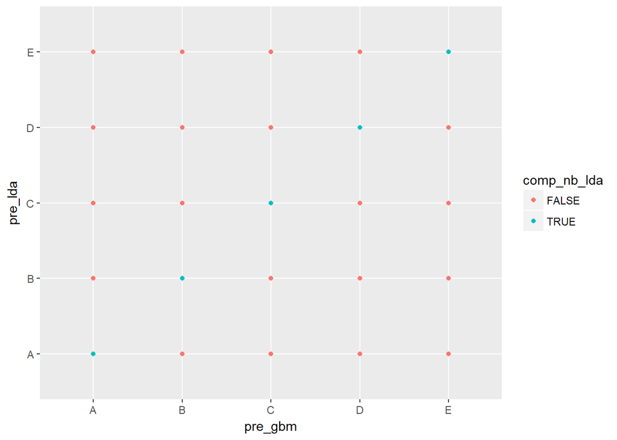

```r
comp_nb_lda<-(pre_gbm==pre_lda)
qplot(pre_gbm,pre_lda,color=comp_nb_lda,data=test_2)
```

```r
#combining random forest and gbm models
set.seed(55555)
comb_df<-data.frame(pre_gbm,pre_rf,classe=test_2$classe)
comb_modfit<-train(classe~.,data=comb_df,method="gam",verbose=FALSE)
```

[output not shown]

[output cut: 76 more lines]

[output not shown]

```r
comb_pred<-predict(comb_modfit,comb_df)
confusionMatrix(comb_pred,test_2$classe)
```

```
## Confusion Matrix and Statistics
##
##           Reference
## Prediction    A    B    C    D    E
##          A 1674    2    0    0    0
##          B    0 1137 1026  964 1082
##          C    0    0    0    0    0
##          D    0    0    0    0    0
##          E    0    0    0    0    0
##
## Overall Statistics
##
##                Accuracy : 0.4777
##                  95% CI : (0.4648, 0.4905)
##     No Information Rate : 0.2845
##     P-Value [Acc > NIR] : < 2.2e-16
##
##                   Kappa : 0.3308
##  Mcnemar's Test P-Value : NA
##
## Statistics by Class:
##
##                      Class: A Class: B Class: C Class: D Class: E
## Sensitivity            1.0000   0.9982   0.0000   0.0000   0.0000
## Specificity            0.9995   0.3527   1.0000   1.0000   1.0000
## Pos Pred Value         0.9988   0.2701      NaN      NaN      NaN
## Neg Pred Value         1.0000   0.9988   0.8257   0.8362   0.8161
## Prevalence             0.2845   0.1935   0.1743   0.1638   0.1839
## Detection Rate         0.2845   0.1932   0.0000   0.0000   0.0000
## Detection Prevalence   0.2848   0.7152   0.0000   0.0000   0.0000
## Balanced Accuracy      0.9998   0.6755   0.5000   0.5000   0.5000
```

```r
predict_final<-predict(rf_fit,newdata=testing_2)
predict_final
```

```
##  1  2  3  4  5  6  7  8  9 10 11 12 13 14 15 16 17 18 19 20
##  B  A  B  A  A  E  D  B  A  A  B  C  B  A  E  E  A  B  B  B
## Levels: A B C D E
```

The above is prediction of Class types for given testing data of 20 sets.

## Exploratory data analysis

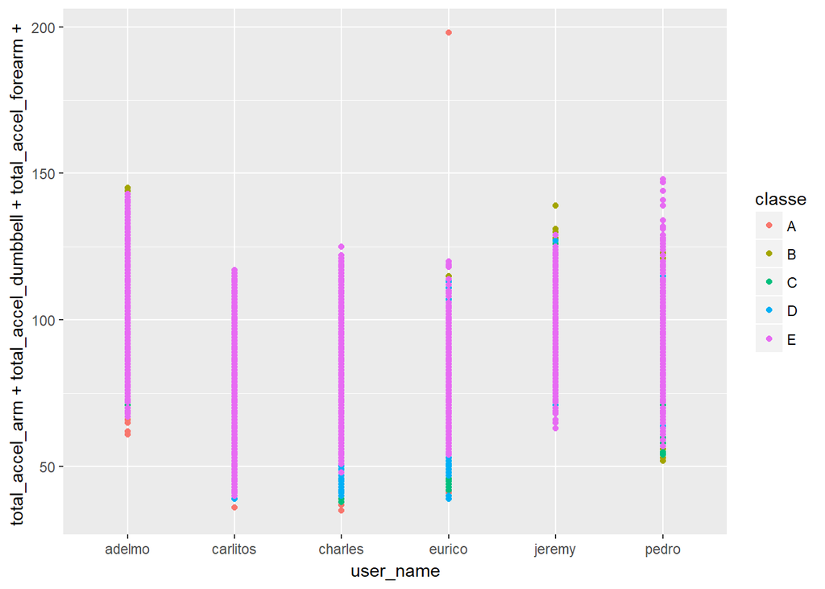

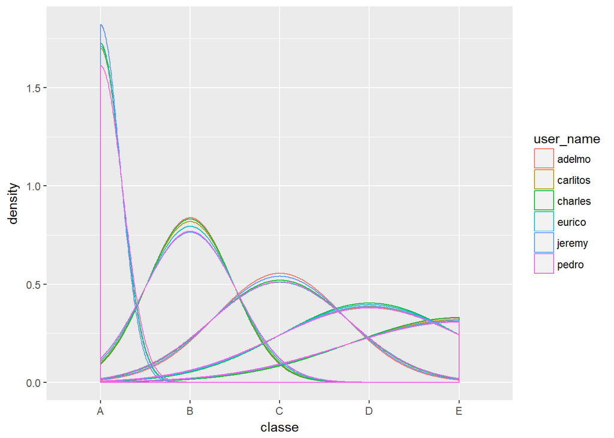